# Music genre feature analysis

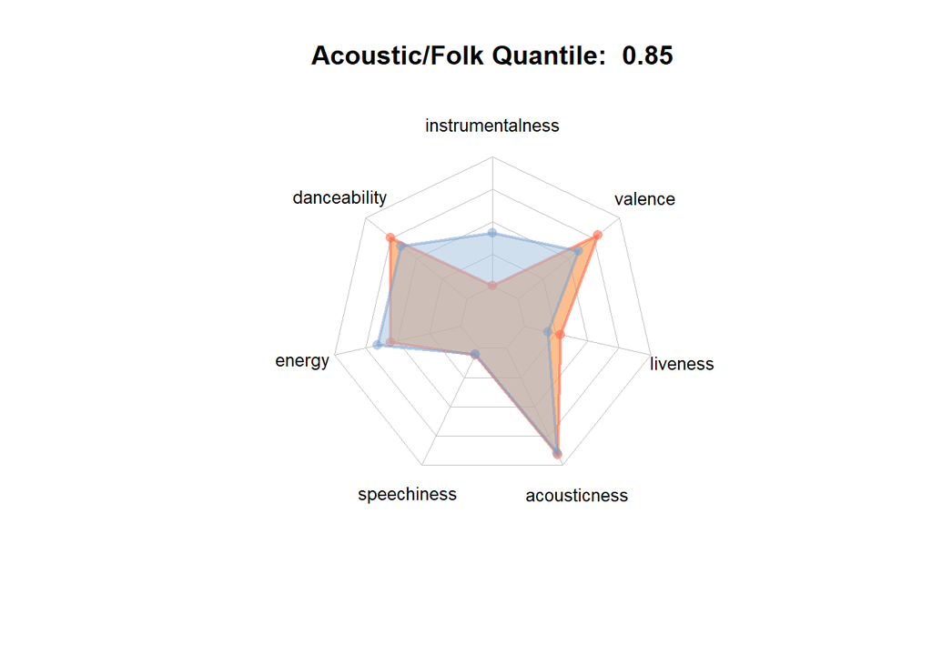

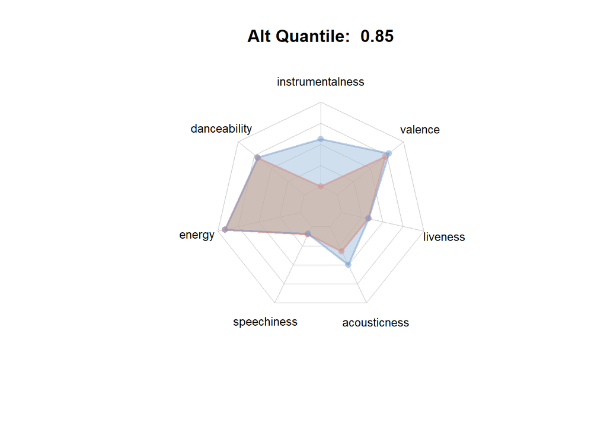

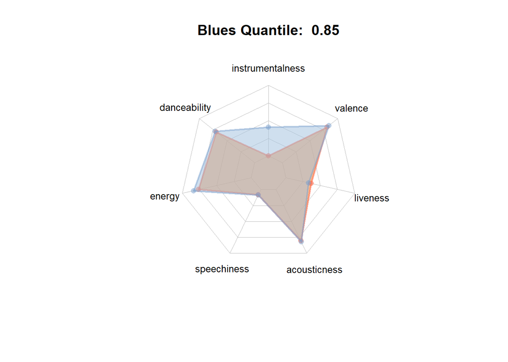

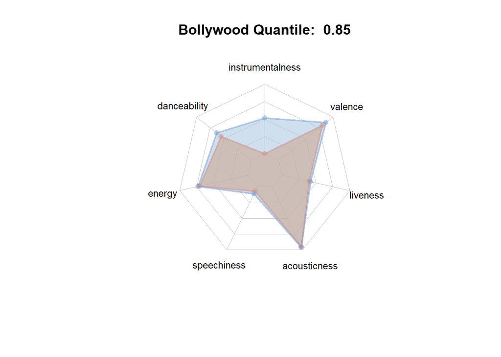

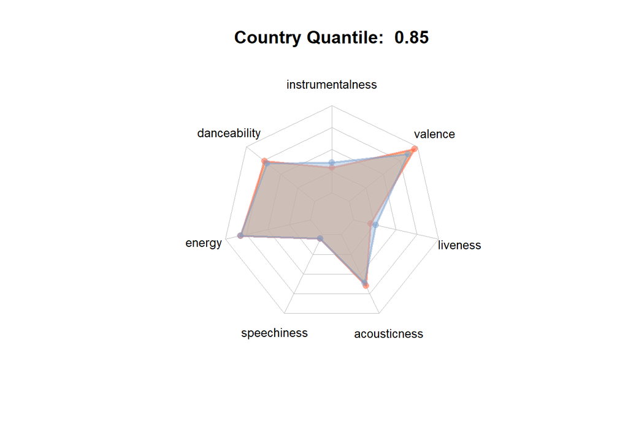

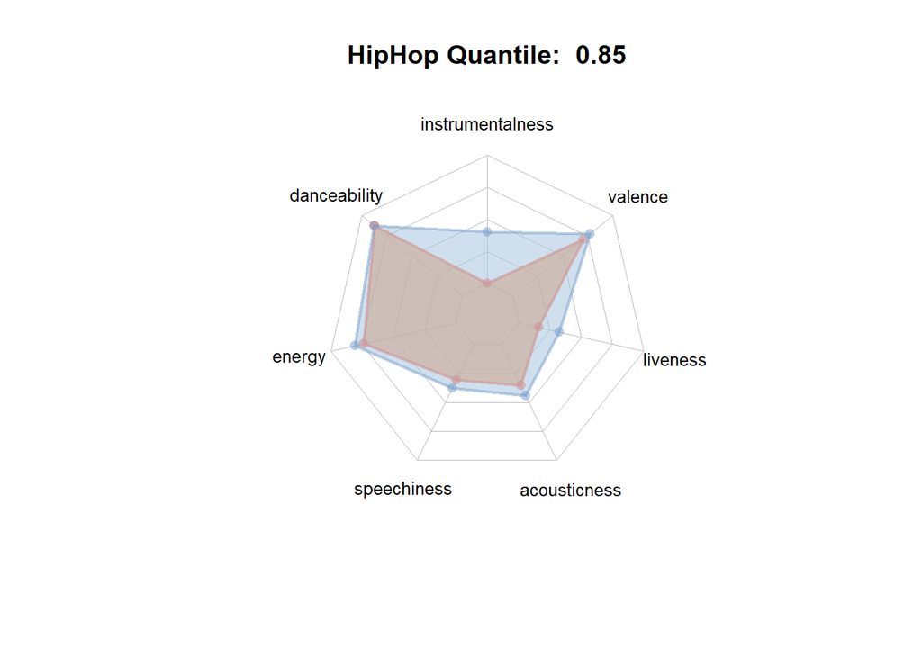

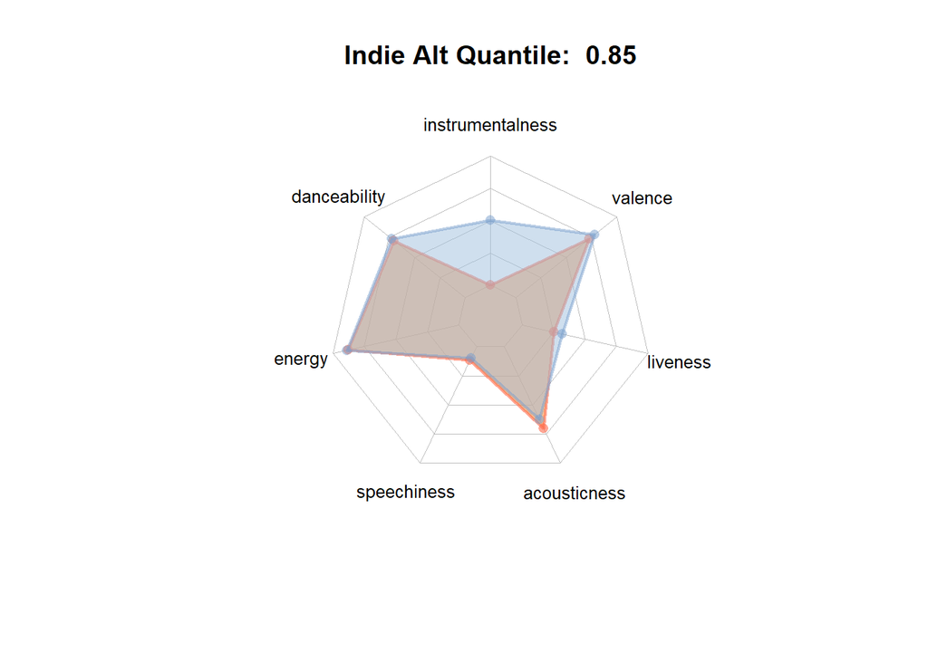

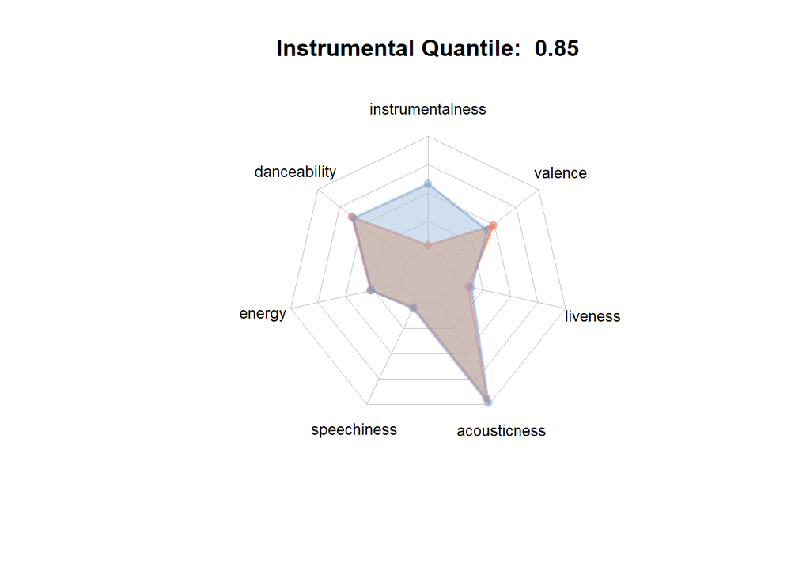

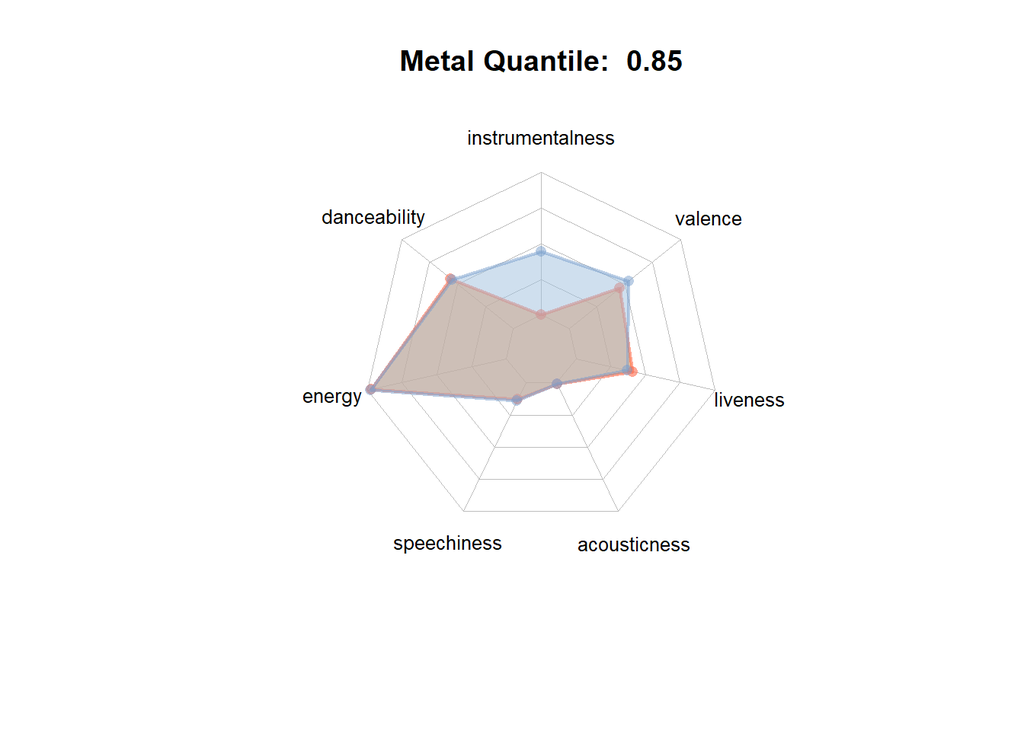

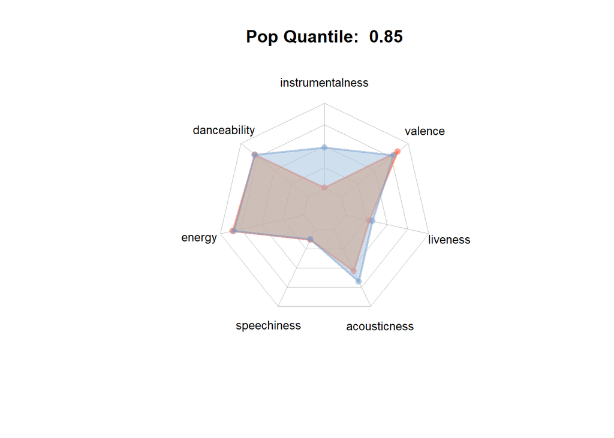

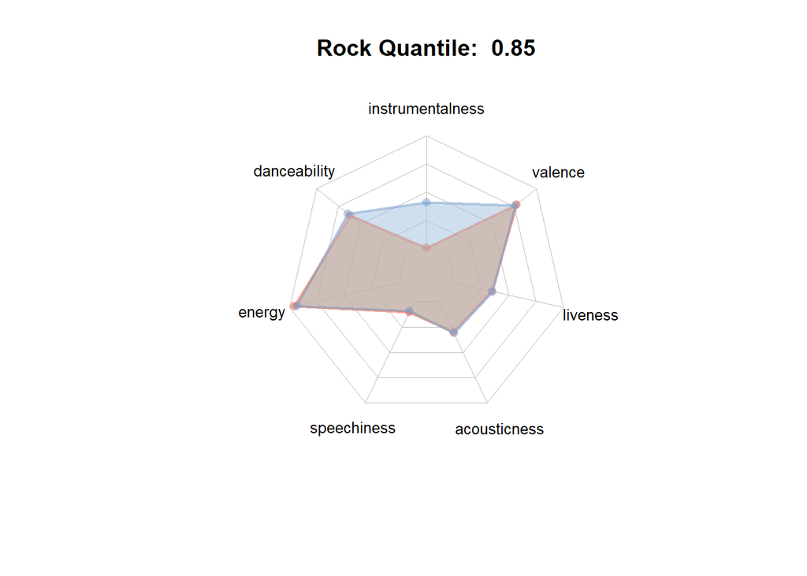

```r
by_genre %>% group_map(~radar_plot_tb_popular_with_measure(.x, .y, prob=0.85))
```

It does seem like the difference in stats data is a bit more extreme when selecting more extreme percentiles!

## 6. Comparing distribution of keys between each genre and the dataset

The key of a song ranges from -1 to 10, -1 means the key is not detected, where 1 - 10 is mapped to pitch classes using [the standard mapping](https://en.wikipedia.org/wiki/Pitch_class). E.g. 0 = C, 1 = C♯/D♭, 2 = D, and so on. It’s an important property of a song, and it’d be interesting to see the key distribution for each genre compare to the dataset.

Here, we combine the undersampling, getting unique value counts, and converting wide format to long format techniques we used before to create the data table for plotting.

```r
create_keys_data_tb <- function(group_tb, group_nrow) {
  df_sample <- df[sample(nrow(df), group_nrow), ]
  data_tb <- as.data.frame(table(df_sample$key))
  data_tb$group_key <- as.data.frame(table(group_tb$key))$Freq
  colnames(data_tb) <- c("key", "all_key", "group_key")
  data_tb <- pivot_longer(data_tb, cols = c("all_key", "group_key"))
  data_tb$name <- factor(data_tb$name, c("all_key", "group_key"))

  return(data_tb)
}
```

Here we plot bar graph for two variables, the key distribution for all data and for a genre subgroup.

```r
bar_plot_tb_compare<- function(tb, group_by_column) {
  data_tb <- create_keys_data_tb(tb, nrow(tb))
  tb_genre <- group_by_column$Genre

  p <- data_tb %>%
  ggplot( aes(key, value, fill=name)) +
    geom_bar(stat="identity", position = "dodge") +
    scale_fill_manual(values=c("#4793AF", "#FFC470")) +
    theme_ipsum() +
    ylab("value counts") +
    ggtitle(paste("Key distribution: All songs vs. Genre: ", tb_genre ))
}
```